# Lab 02: Difference-In-Difference

### Question 4: Comparing DID and ITS Approaches

Now let’s compare two different approaches to analyzing policy interventions using a different dataset with monthly observations.

```r
## Load and preview the data
URL2 <- "https://raw.githubusercontent.com/DS4PS/pe4ps-textbook/master/labs/DATA/time-series-diff-n-diff-comparison.csv"
dat <- read.csv(URL2, stringsAsFactors = FALSE)
rbind(head(dat, 3), tail(dat, 3))
```

```
##      nhood quadrant   group month year time treat post.treat time.since crimes treat.x.post
## 1    NH-01      Q-A   treat     1 1994    1     1          0          0    107            0
## 2    NH-01      Q-B control     1 1994    1     0          0          0     96            0
## 3    NH-01      Q-C   treat     1 1994    1     1          0          0     92            0
## 1246 NH-04      Q-X control    12 1997   48     0          1         24    192            0
## 1247 NH-04      Q-Y   treat    12 1997   48     1          1         24    214            1
## 1248 NH-04      Q-Z control    12 1997   48     0          1         24    196            0
```

This dataset contains 48 months of data. The vacant lot clean-up occurred between months 24 and 25.

#### Visualize the data

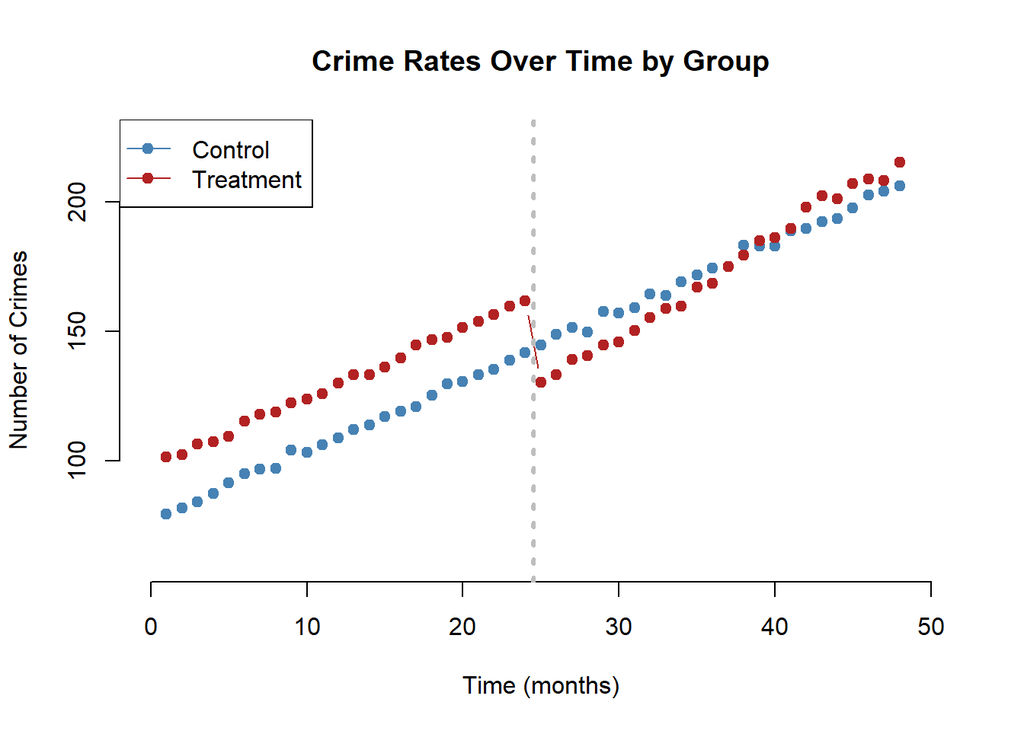

```r
# Calculate averages by group and time
ts_control <- dat %>%
  filter(group == "control") %>%
  group_by(time) %>%
  summarize(ave = mean(crimes), .groups = "drop")

ts_treat <- dat %>%
  filter(group == "treat") %>%
  group_by(time) %>%
  summarize(ave = mean(crimes), .groups = "drop")

# Plot
plot(ts_control$time, ts_control$ave, type = "b", pch = 19, col = "steelblue",
     xlab = "Time (months)", ylab = "Number of Crimes",
     main = "Crime Rates Over Time by Group",
     xlim = c(0, 50), ylim = c(60, 225), bty = "n")
points(ts_treat$time, ts_treat$ave, type = "b", pch = 19, col = "firebrick")
abline(v = 24.5, lty = 3, col = "gray", lwd = 3)

legend("topleft", legend = c("Control", "Treatment"),
       col = c("steelblue", "firebrick"), pch = 19, lty = 1)
```

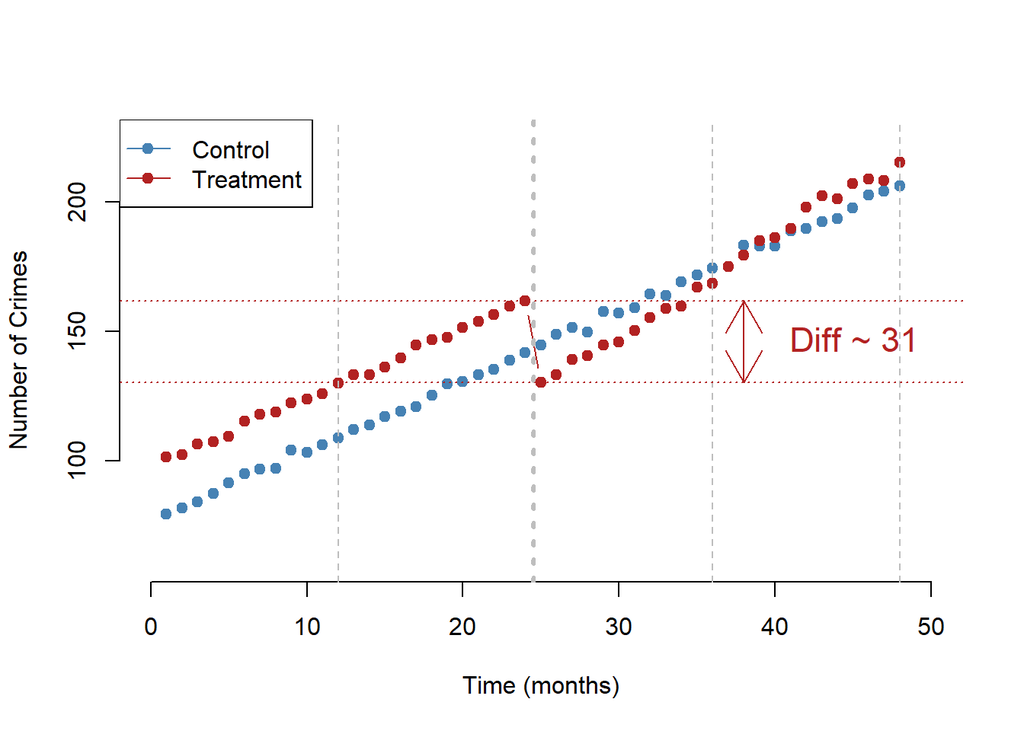

```r
ts1 <-
  dat %>%
  filter( group == "control" ) %>%
  group_by( time ) %>%
  summarize( ave=mean( crimes ) )

ts2 <-
  dat %>%
  filter( group == "treat" ) %>%
  group_by( time ) %>%
  summarize( ave=mean( crimes ) )

y.24 <- ts2$ave[24]
y.25 <- ts2$ave[25]
diff <- y.24 - y.25

plot( ts1$time, ts1$ave, type="b", pch=19, col="steelblue", bty="n",
      xlab="Time (months)", ylab="Number of Crimes",
      xlim=c(0,50), ylim=c(60,225) )
points( ts2$time, ts2$ave, type="b", pch=19, col="firebrick" )
abline( v=c(12,36,48), lty=2, col="gray" )
abline( v=24.5, lty=3, col="gray", lwd=3 )
abline( h=c(y.24,y.25), lty=3, col="firebrick" )

arrows( x0=38, y0=y.24, y1=y.25, col="firebrick", code=3 )
text( x=40, y=mean(c(y.24,y.25)),
      paste0( "Diff ~ ", round(diff,0) ),
      col="firebrick", pos=4, cex=1.4 )
legend("topleft", legend = c("Control", "Treatment"),
       col = c("steelblue", "firebrick"), pch = 19, lty = 1)
```

#### Difference-in-Difference

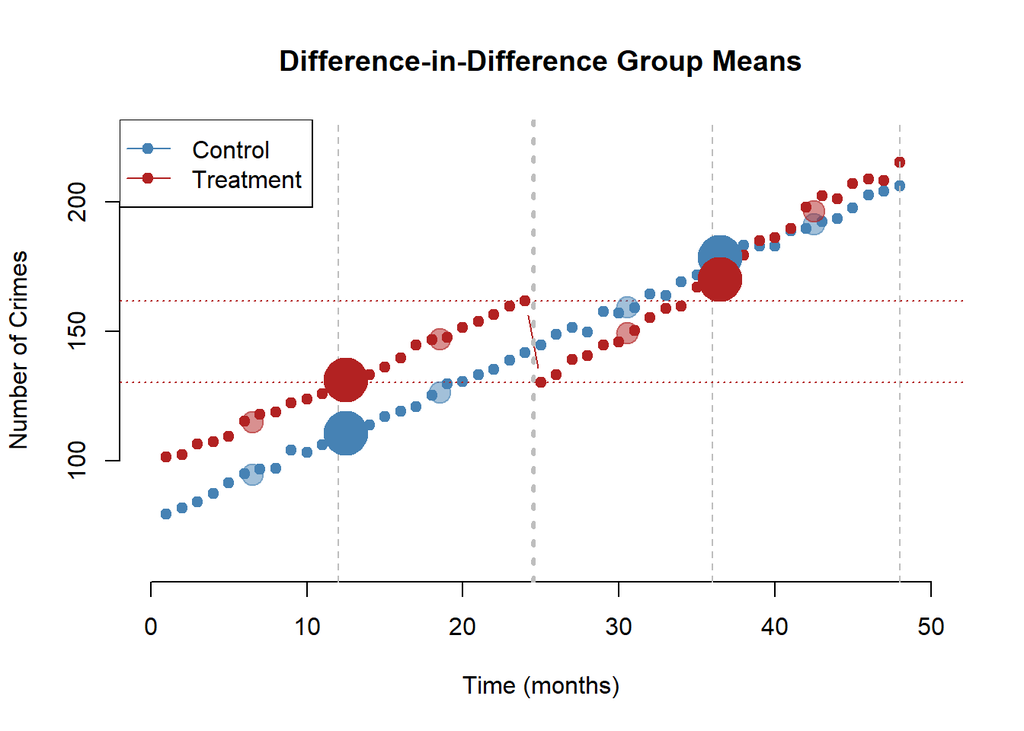

```r
C1 <- mean( dat$crimes[ dat$year == 1994 & dat$group == "control" ] )
C2 <- mean( dat$crimes[ dat$year == 1995 & dat$group == "control" ] )
C3 <- mean( dat$crimes[ dat$year == 1996 & dat$group == "control" ] )
C4 <- mean( dat$crimes[ dat$year == 1997 & dat$group == "control" ] )

T1 <- mean( dat$crimes[ dat$year == 1994 & dat$group == "treat" ] )
T2 <- mean( dat$crimes[ dat$year == 1995 & dat$group == "treat" ] )
T3 <- mean( dat$crimes[ dat$year == 1996 & dat$group == "treat" ] )
T4 <- mean( dat$crimes[ dat$year == 1997 & dat$group == "treat" ] )

dd.C1 <- mean( dat$crimes[ dat$post == 0 & dat$group == "control" ] )
dd.C2 <- mean( dat$crimes[ dat$post == 1 & dat$group == "control" ] )

dd.T1 <- mean( dat$crimes[ dat$post == 0 & dat$group == "treat" ] )
dd.T2 <- mean( dat$crimes[ dat$post == 1 & dat$group == "treat" ] )

plot( ts1$time, ts1$ave, type="b", pch=19, col="steelblue", bty="n",
      xlab="Time (months)", ylab="Number of Crimes",
      main="Difference-in-Difference Group Means",
      xlim=c(0,50), ylim=c(60,225) )
points( ts2$time, ts2$ave, type="b", pch=19, col="firebrick" )
abline( v=c(12,36,48), lty=2, col="gray" )
abline( v=24.5, lty=3, col="gray", lwd=3 )
abline( h=c(y.24,y.25), lty=3, col="firebrick" )

points( c(6.5,18.5,30.5,42.5), c(C1,C2,C3,C4),
        pch=19, col=adjustcolor("steelblue",alpha=0.5), cex=2 )
points( c(6.5,18.5,30.5,42.5), c(T1,T2,T3,T4),
        pch=19, col=adjustcolor("firebrick",alpha=0.5), cex=2 )

points( c(12.5,36.5), c(dd.C1,dd.C2+3), col="steelblue", pch=19, cex=4 )
points( c(12.5,36.5), c(dd.T1,dd.T2-3), col="firebrick", pch=19, cex=4 )
legend("topleft", legend = c("Control", "Treatment"),
       col = c("steelblue", "firebrick"), pch = 19, lty = 1)
```

```r
# Diff-in-Diff Model
m1 <- lm(crimes ~ treat + post.treat + treat.x.post, data = dat)

stargazer(m1,
#          type = "html",
          type = "text",
          digits = 2,
          omit.stat = c("f", "rsq", "adj.rsq", "ser"),
          title = "Difference-In-Difference",
          intercept.bottom = FALSE,
          dep.var.labels = "Crimes",
          covariate.labels = c("Intercept (a0)",
                               "Treatment Group (a1)",
                               "Post-Treatment Period (a2)",
                               "Treat × Post (a3)"))
```

[output not shown]